# IST 707 Assignment 3 - NBC, KNN, SVM, and Ensemble Learning

## Introduction

##### The aim of this assignment is to predict if a person has a disease or not to the maximum possible accurcy using the machine learning models. We will be using classification algorithms as this is a binary classification problem.

## Contents

### Step 1: Data Preparation

### Step 2: Building & Tuning Models

##### a) Naive Bayes Classifier

##### b) K Nearest Neighbour Classifier

##### c) Linear Support Vector Machine Classifier

##### d) Gaussian Support Vector Machine Classifier

##### e) Random Forest Classifier

##### f) Gradient Boosting Classifier

### Step 3: Predictions

##### a) Naive Bayes Classifier

##### b) K Nearest Neighbour Classifier

##### c) Linear Support Vector Machine Classifier

##### d) Gaussian Support Vector Machine Classifier

##### e) Random Forest Classifier

##### f) Gradient Boosting Classifier

#### Importing Libraries

```python
import pandas as pd
import numpy as np
import matplotlib.pyplot as plt
import matplotlib as mpl
import seaborn as sns
import matplotlib.gridspec as gridspec
from sklearn.model_selection import train_test_split
from sklearn.model_selection import GridSearchCV
from sklearn import metrics
from sklearn.compose import ColumnTransformer
from sklearn.preprocessing import OneHotEncoder, StandardScaler, RobustScaler
```

## Step 1: Data Preparation

##### The file we are working with today is a data set consisting of patients’ information with respect to a certain unspecified disease. The data set consists of features like Age, Gender, Blood pressure and other necessary information.

### a) Data Cleaning

##### Reading the data

```python
df = pd.read_csv('Disease Prediction Training(1).csv')
df.head()
```

|  | Age | Gender | Height | Weight | High Blood Pressure | Low Blood Pressure | Cholesterol | Glucose | Smoke | Alcohol | Exercise | Disease |
| --- | --- | --- | --- | --- | --- | --- | --- | --- | --- | --- | --- | --- |
| 0 | 59 | female | 167 | 88.0 | 130 | 68 | normal | normal | 0 | 0 | 1 | 0 |
| 1 | 64 | female | 150 | 71.0 | 140 | 100 | normal | normal | 0 | 0 | 0 | 1 |
| 2 | 41 | female | 166 | 83.0 | 100 | 70 | normal | normal | 0 | 1 | 1 | 0 |
| 3 | 50 | male | 172 | 110.0 | 130 | 80 | normal | normal | 1 | 0 | 1 | 0 |
| 4 | 39 | female | 162 | 61.0 | 110 | 80 | high | high | 0 | 0 | 1 | 0 |

##### Checking the dimensions of the dataframe

```python
print('Dimensions: ',df.shape)
```

```
Dimensions:  (49000, 12)
```

##### Checking the datatypes of each column of the dataframe

```python
df.dtypes
```

```
Age                      int64
Gender                  object
Height                   int64
Weight                 float64
High Blood Pressure      int64
Low Blood Pressure       int64
Cholesterol             object
Glucose                 object
Smoke                    int64
Alcohol                  int64
Exercise                 int64
Disease                  int64
dtype: object
```

##### Checking the unique values in the columns with object datatype

```python
for c in df:
    if df[c].dtypes.name == 'object':
        print(c,':',df[c].unique())
```

```
Gender : ['female' 'male']
Cholesterol : ['normal' 'high' 'too high']
Glucose : ['normal' 'high' 'too high']
```

##### Checking the range (min,max) for the columns with integer/float datatype

```python
for c in df:
    if df[c].dtypes.name != 'object':
        print(c,":",df[c].min(),"-",df[c].max())
```

```
Age : 29 - 64
Height : 55 - 207
Weight : 10.0 - 200.0
High Blood Pressure : -150 - 14020
Low Blood Pressure : 0 - 11000
Smoke : 0 - 1
Alcohol : 0 - 1
Exercise : 0 - 1
Disease : 0 - 1
```

##### Checking for missing values

```python
(df.isnull().sum()/df.shape[0])*100
```

```
Age                    0.0
Gender                 0.0
Height                 0.0
Weight                 0.0
High Blood Pressure    0.0
Low Blood Pressure     0.0
Cholesterol            0.0
Glucose                0.0
Smoke                  0.0
Alcohol                0.0
Exercise               0.0
Disease                0.0
dtype: float64
```

##### Using the above observations, we can make the conclusions:

- There are no missing values, hence there is no need to impute the data.
- Certain features which are categorical features like, Smoke and Exercise are read as integer features. Hence, they will have to be changed.
- Features High Blood Pressure and Low Blood Pressure have values need to be checked and tuned to be correctly aligned with the rest of the data.

##### But before all this lets check the data for duplicates

```python
df.duplicated().sum()
```

```
1752
```

###### As we can see, there are 1752 duplicate rows in the data. This is detrimental to our data as it will affect the training process of our models negatively. We want to make sure the data is in its purest form without any repetitions.

```python
# having a look at the rows which are duplicates
dup=df[df.duplicated(keep=False)]
dup=dup.sort_values(by=['Age', 'Gender','Height','Weight'])
dup.head(10)
```

|  | Age | Gender | Height | Weight | High Blood Pressure | Low Blood Pressure | Cholesterol | Glucose | Smoke | Alcohol | Exercise | Disease |
| --- | --- | --- | --- | --- | --- | --- | --- | --- | --- | --- | --- | --- |
| 12891 | 39 | female | 155 | 55.0 | 110 | 70 | normal | normal | 0 | 0 | 1 | 0 |
| 34797 | 39 | female | 155 | 55.0 | 110 | 70 | normal | normal | 0 | 0 | 1 | 0 |
| 4898 | 39 | female | 156 | 69.0 | 120 | 80 | normal | normal | 0 | 0 | 1 | 0 |
| 21661 | 39 | female | 156 | 69.0 | 120 | 80 | normal | normal | 0 | 0 | 1 | 0 |
| 15366 | 39 | female | 157 | 56.0 | 110 | 70 | normal | normal | 0 | 0 | 1 | 0 |
| 39508 | 39 | female | 157 | 56.0 | 110 | 70 | normal | normal | 0 | 0 | 1 | 0 |
| 5353 | 39 | female | 158 | 58.0 | 110 | 70 | normal | normal | 0 | 0 | 1 | 0 |
| 26395 | 39 | female | 158 | 58.0 | 110 | 70 | normal | normal | 0 | 0 | 1 | 0 |
| 23868 | 39 | female | 158 | 64.0 | 120 | 80 | normal | normal | 0 | 0 | 1 | 0 |
| 30184 | 39 | female | 158 | 64.0 | 120 | 80 | normal | normal | 0 | 0 | 1 | 0 |

##### Removing duplicate rows

```python
df=df.drop_duplicates()
df.duplicated().sum()
```

```
0
```

##### Now that we are done with removing duplicates, we check the columns relating to Blood Pressure.

##### As we saw with the range, there were some negative values in the High Blood Pressure column. Since blood pressure can never be negative, we will have to deal with those values.

```python
df[df['High Blood Pressure']<0]
```

|  | Age | Gender | Height | Weight | High Blood Pressure | Low Blood Pressure | Cholesterol | Glucose | Smoke | Alcohol | Exercise | Disease |
| --- | --- | --- | --- | --- | --- | --- | --- | --- | --- | --- | --- | --- |
| 20969 | 50 | female | 162 | 74.0 | -140 | 90 | normal | normal | 0 | 0 | 1 | 1 |
| 25368 | 64 | male | 160 | 59.0 | -120 | 80 | normal | normal | 0 | 0 | 0 | 0 |
| 26599 | 41 | female | 165 | 78.0 | -100 | 80 | high | normal | 0 | 0 | 1 | 0 |
| 27421 | 63 | male | 168 | 59.0 | -150 | 80 | normal | normal | 0 | 0 | 1 | 1 |
| 29572 | 60 | male | 161 | 90.0 | -115 | 70 | normal | normal | 0 | 0 | 1 | 0 |
| 31308 | 42 | female | 153 | 54.0 | -100 | 70 | normal | normal | 0 | 0 | 1 | 0 |
| 33838 | 40 | male | 168 | 50.0 | -120 | 80 | high | normal | 0 | 0 | 0 | 1 |

##### We can assume that this was a data entry error and we can convert these into positive values

```python
df.loc[df['High Blood Pressure']<0,'High Blood Pressure']=df[df['High Blood Pressure']<0]['High Blood Pressure'].apply(lambda x: abs(x))
df[df['High Blood Pressure']<0]
```

|  | Age | Gender | Height | Weight | High Blood Pressure | Low Blood Pressure | Cholesterol | Glucose | Smoke | Alcohol | Exercise | Disease |
| --- | --- | --- | --- | --- | --- | --- | --- | --- | --- | --- | --- | --- |

##### We would also need to check for values for cases where Low Blood Pressure values are greater that High Blood Pressure values and deal with them

```python
df[df['Low Blood Pressure']>df['High Blood Pressure']].shape[0]
```

```
858
```

##### Given the count, we can remedy this by swapping the values.

```python
df.loc[df['Low Blood Pressure']>df['High Blood Pressure'],['Low Blood Pressure','High Blood Pressure']] = df.loc[df['Low Blood Pressure']>df['High Blood Pressure'],['High Blood Pressure','Low Blood Pressure']].values
df[df['Low Blood Pressure']>df['High Blood Pressure']].shape[0]
```

```
0
```

###### We also observed that the maximum values of the Blood Pressure columns were abnormally high. A simple search will tell you that the highest blood pressure calculated for an individual was 370/360. Keeping this in mind, we will check for entries with values greater than that.

```python
df[(df['Low Blood Pressure']>360) | (df['High Blood Pressure']>370)].shape[0]
```

```
686
```

##### We can remedy this by removing the follwoing entires

```python
df=df.drop(df[(df['Low Blood Pressure']>360) | (df['High Blood Pressure']>370)].index)
df[(df['Low Blood Pressure']>360) | (df['High Blood Pressure']>370)].shape[0]
```

```
0
```

##### Checking the final dimensions of the dataframe

```python
print('Dimensions: ',df.shape)
```

```
Dimensions:  (46562, 12)
```

##### Now that data cleaning is done, we can move on towards Data Analytics

### b) Data analysis

##### Lets start by checking the correlation between the different features

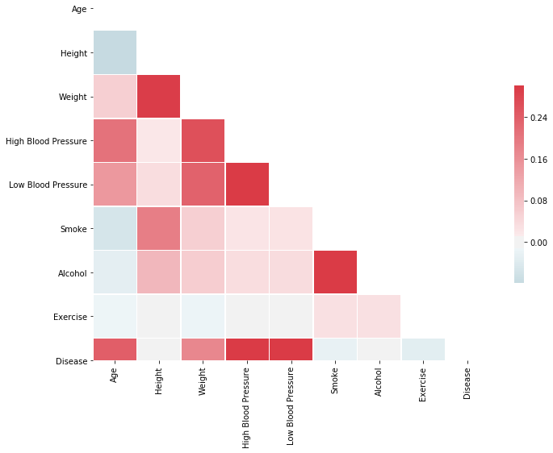

```python
corr = df.corr()
mask = np.triu(np.ones_like(corr, dtype=np.bool))
f, ax = plt.subplots(figsize=(11, 9))
cmap = sns.diverging_palette(220, 10, as_cmap=True)
sns.heatmap(corr, mask=mask, cmap=cmap, vmax=.3, center=0,
            square=True, linewidths=.5, cbar_kws={"shrink": .5})
plt.show()
```

- We can see that disease has high correlation with features Age, High Blood Pressure and Low Blood Pressure
- A feature that is not provided here but is considered during disease studies is the body mass index (BMI). Though we are not provided with the BMI of the patients, we can nevertheless calculate it using the Weight and Height features.

##### The formula is as follows :

$$ BMI = \frac{Weight}{Height^{2}} $$

```python
# Calculating BMI
df['BMI']=df['Weight']/((df['Height']*df['Height'])/10000)
```

##### Lets check how evenly is our dependent feature distributed

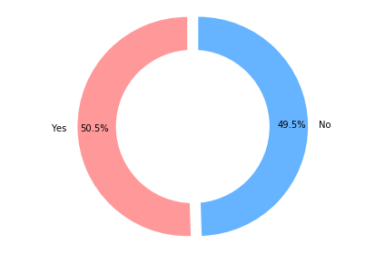

```python
labels = ['Yes', 'No']
sizes = df['Disease'].value_counts().values
colors = ['#ff9999','#66b3ff']
explode = (0.05,0.05)
fig1, ax1 = plt.subplots()
plt.pie(sizes, colors = colors, labels=labels, autopct='%1.1f%%', startangle=90, pctdistance=0.85, explode = explode)
centre_circle = plt.Circle((0,0),0.70,fc='white')
fig = plt.gcf()
fig.gca().add_artist(centre_circle)
ax1.axis('equal')
plt.tight_layout()
plt.show()
```

##### Checking the Categorical variables

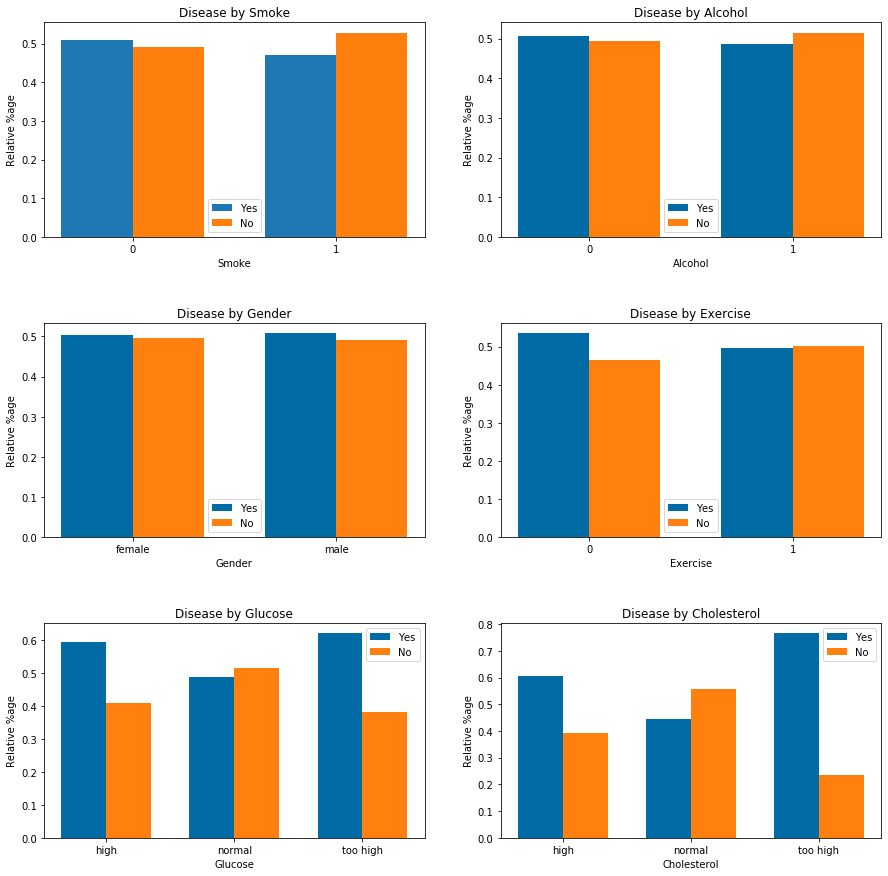

```python
fig = plt.figure(figsize=(15, 15))
outer = gridspec.GridSpec(3, 2, wspace=0.2, hspace=0.4)
col=['Smoke','Alcohol','Gender','Exercise','Glucose','Cholesterol']

for i in range(6):
    ax = plt.Subplot(fig, outer[i])

    dist_data = pd.concat([df[df.Disease == 1].groupby(col[i])[col[i]].count()
                     ,df[df.Disease == 0].groupby(col[i])[col[i]].count()],axis=1)
    col1,col2 = (col[i]+'_Yes'),(col[i]+'_No')
    dist_data.columns = [(col[i]+'_Yes'),(col[i]+'_No')]

    dist_data_Yes = dist_data[col1]/(dist_data[col1]+dist_data[col2])

    dist_data_No = dist_data[col2]/(dist_data[col1]+dist_data[col2])

    x = np.arange(len(dist_data))
    width = 0.35

    mpl.style.use('tableau-colorblind10')
    ax.bar(x - width/2, dist_data_Yes, width, label='Yes')
    ax.bar(x + width/2, dist_data_No, width, label='No')

    ax.set_ylabel('Relative %age')
    ax.set_xlabel(col[i])
    ax.set_title('Disease by '+col[i])
    ax.set_xticks(x)
    ax.set_xticklabels(dist_data.index)
    ax.legend()

    fig.add_subplot(ax)

fig.show()
```

#### We can conclude that:

- Gender is the feature with the lowest distinguishing value. The likelihood of having the disease irrespective of the gender is ~50%. Hence this feature would not be a contributing on for the model(s).
- Glucose and Cholesterol have the highest distinguishing factor. The likelihood of having the disease increases for both the features from normal to too high. Hence these features will have high contribution to the model(s).

##### Checking the Numerical variables

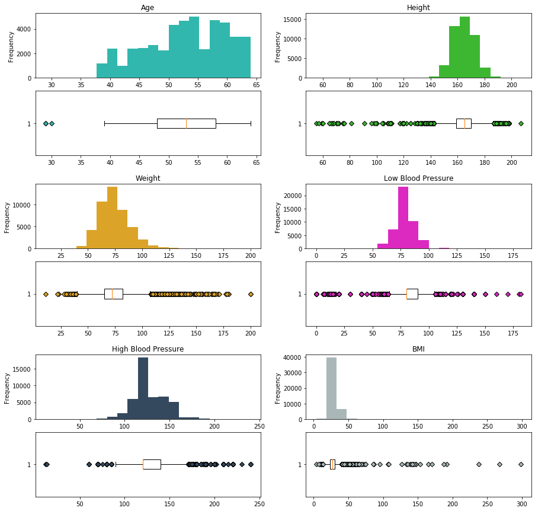

```python
fig = plt.figure(figsize=(15, 15))
outer = gridspec.GridSpec(3, 2, wspace=0.2, hspace=0.2)
cols=['Age','Height','Weight','Low Blood Pressure','High Blood Pressure','BMI']
colors = ['#32B7AE','#3DB732','#DCA329','#DC29C0','#34495E','#AAB7B8']

for i in range(6):
    inner = gridspec.GridSpecFromSubplotSpec(2, 1,
                    subplot_spec=outer[i], wspace=0.1, hspace=0.2)

    for j in range(2):
        ax = plt.Subplot(fig, inner[j])
        if j == 0 :
            ax.hist(df[cols[i]],color=colors[i],bins=20)
            ax.set_xlabel('Range')
            ax.set_ylabel('Frequency')
            ax.set_title(cols[i])
        elif j == 1:
            ax.boxplot(df[cols[i]],vert=False, flierprops=dict(markerfacecolor=colors[i], marker='D'))
        fig.add_subplot(ax)

fig.show()
```

#### We can conclude that:

- Features Height, Weight, Low Blood Pressure and High Blood Pressure are normally distributed
- Feature BMI is right skewed, and Age is left skewed.
- All the features have outliers. These will have to be dealt with using scaling before running certain models.
- We can also assume that since we are including BMI, there is no need to include Height and Weight when running the models.

## Step 2: Building & Tuning Models

#### Before moving to model tuning, we need to set up the scoring parameter we are using to fine tune the model. In case of predicting if someone has a disease or not, we need to reduce the false positives. Hence the best metric(s) to do that would be precision & accuracy.

### a) Naive Bayes Classifier

##### Naïve Bayes Classifier uses Bayes Theorem and Markov Models to make predictions.

```python
#creating a new dataframe for NBC
nbc_df = df
```

##### Segregating the dependent and the independent variables and transforming the independent variables

```python
target=nbc_df['Disease']
nbc_df=nbc_df.drop(columns=['Disease','Gender'])
nbc_df = pd.get_dummies(nbc_df,columns=['Smoke','Alcohol','Exercise','Glucose','Cholesterol'])
nbc_df.head()
```

|  | Age | Height | Weight | High Blood Pressure | Low Blood Pressure | BMI | Smoke_0 | Smoke_1 | Alcohol_0 | Alcohol_1 | Exercise_0 | Exercise_1 | Glucose_high | Glucose_normal | Glucose_too high | Cholesterol_high | Cholesterol_normal | Cholesterol_too high |
| --- | --- | --- | --- | --- | --- | --- | --- | --- | --- | --- | --- | --- | --- | --- | --- | --- | --- | --- |
| 0 | 59 | 167 | 88.0 | 130 | 68 | 31.553659 | 1 | 0 | 1 | 0 | 0 | 1 | 0 | 1 | 0 | 0 | 1 | 0 |
| 1 | 64 | 150 | 71.0 | 140 | 100 | 31.555556 | 1 | 0 | 1 | 0 | 1 | 0 | 0 | 1 | 0 | 0 | 1 | 0 |
| 2 | 41 | 166 | 83.0 | 100 | 70 | 30.120482 | 1 | 0 | 0 | 1 | 0 | 1 | 0 | 1 | 0 | 0 | 1 | 0 |
| 3 | 50 | 172 | 110.0 | 130 | 80 | 37.182261 | 0 | 1 | 1 | 0 | 0 | 1 | 0 | 1 | 0 | 0 | 1 | 0 |
| 4 | 39 | 162 | 61.0 | 110 | 80 | 23.243408 | 1 | 0 | 1 | 0 | 0 | 1 | 1 | 0 | 0 | 1 | 0 | 0 |

##### Spliting to training and testing

```python
X_train, X_test, y_train, y_test = train_test_split(nbc_df,target,test_size=0.3,random_state=123)
```

##### Now that we have the Train and test data, we can feed this data to the different NBC models, ie. Gaussian, Bernoulli and Multinomial

```python
from sklearn.naive_bayes import GaussianNB, BernoulliNB, MultinomialNB
```

##### Running and Checking the performance of the GaussianNB

```python
#Gaussian Naive Bayes
gnb= GaussianNB()
gnb.fit(X_train, y_train)
y_pred = gnb.predict(X_test)

#performance metrics
print("Precision - ",round(metrics.precision_score(y_test,y_pred)*100,2))
print("Accuracy - ",round(metrics.accuracy_score(y_test,y_pred)*100,2))
print("Recall - ",round(metrics.recall_score(y_test,y_pred)*100,2))
print("F1 Score - ",round(metrics.f1_score(y_test,y_pred)*100,2))
```

```
Precision -  71.56
Accuracy -  66.73
Recall -  55.98
F1 Score -  62.82
```

##### Running and Checking the performance of the Bernoulli NB

```python
#Bernoulli Naive Bayes
bnb = BernoulliNB()
bnb.fit(X_train, y_train)
y_pred = bnb.predict(X_test)

#performance metrics
print("Precision - ",round(metrics.precision_score(y_test,y_pred)*100,2))
print("Accuracy - ",round(metrics.accuracy_score(y_test,y_pred)*100,2))
print("Recall - ",round(metrics.recall_score(y_test,y_pred)*100,2))
print("F1 Score - ",round(metrics.f1_score(y_test,y_pred)*100,2))
```

```
Precision -  64.36
Accuracy -  58.7
Recall -  39.73
F1 Score -  49.13
```

##### Running and Checking the performance of the MultinomialNB

```python
#Multinomial Naive Bayes
mnb = MultinomialNB()
mnb.fit(X_train, y_train)
y_pred = mnb.predict(X_test)

#performance metrics
print("Precision - ",round(metrics.precision_score(y_test,y_pred)*100,2))
print("Accuracy - ",round(metrics.accuracy_score(y_test,y_pred)*100,2))
print("Recall - ",round(metrics.recall_score(y_test,y_pred)*100,2))
print("F1 Score - ",round(metrics.f1_score(y_test,y_pred)*100,2))
```

```
Precision -  73.97
Accuracy -  71.12
Recall -  65.53
F1 Score -  69.49
```

##### We can see that the out of the 3 models, Multinomial performs the best. However, since we cannot do tuning for NBC, lest try to transform the data to see if the model can give us better numbers

##### One thing we can do is try the numerical features.

##### A simple online search will give you the different bifurcations that are possible for the features.

```python
#fucntions to map the different features

def BMI(x):
    if x<18.5:
        return 'underweight'
    elif  18.5<=x<25:
        return 'normal'
    elif  25<=x<30:
        return 'overweight'
    else:
        return 'obese'


def Age_Group(x):
    if x<45:
        return 'young'
    elif  45<=x<65:
        return 'old'

def HighBP_Group(x):
    if x<120:
        return 'normal'
    elif 120<=x<130:
        return 'elevated'
    elif 130<=x<140:
        return 'high'
    else:
        return 'hypertension'


def LowBP_Group(x):
    if x<80:
        return 'normal'
    elif 80<=x<89:
        return 'high'
    else:
        return 'hypertension'
```

##### Mapping the different numerical features and dropping them

```python
nbc_df = df
nbc_df['BMI Group'] = nbc_df.BMI.apply(lambda x: BMI(x))
nbc_df['Age Group'] = nbc_df.Age.apply(lambda x: Age_Group(x))
nbc_df['LBP Group'] = nbc_df['Low Blood Pressure'].apply(lambda x: LowBP_Group(x))
nbc_df['HBP Group'] = nbc_df['High Blood Pressure'].apply(lambda x: HighBP_Group(x))
```

```python
target=nbc_df['Disease']
nbc_df=nbc_df.drop(columns=['Disease','Age','BMI','Height','Weight','Low Blood Pressure','High Blood Pressure','Gender'])
nbc_df = pd.get_dummies(nbc_df,columns=['Smoke','Alcohol','Exercise','Glucose','Cholesterol','BMI Group','Age Group','LBP Group','HBP Group'])
nbc_df.head()
```

|  | Smoke_0 | Smoke_1 | Alcohol_0 | Alcohol_1 | Exercise_0 | Exercise_1 | Glucose_high | Glucose_normal | Glucose_too high | Cholesterol_high | ... | BMI Group_underweight | Age Group_old | Age Group_young | LBP Group_high | LBP Group_hypertension | LBP Group_normal | HBP Group_elevated | HBP Group_high | HBP Group_hypertension | HBP Group_normal |
| --- | --- | --- | --- | --- | --- | --- | --- | --- | --- | --- | --- | --- | --- | --- | --- | --- | --- | --- | --- | --- | --- |
| 0 | 1 | 0 | 1 | 0 | 0 | 1 | 0 | 1 | 0 | 0 | ... | 0 | 1 | 0 | 0 | 0 | 1 | 0 | 1 | 0 | 0 |
| 1 | 1 | 0 | 1 | 0 | 1 | 0 | 0 | 1 | 0 | 0 | ... | 0 | 1 | 0 | 0 | 1 | 0 | 0 | 0 | 1 | 0 |
| 2 | 1 | 0 | 0 | 1 | 0 | 1 | 0 | 1 | 0 | 0 | ... | 0 | 0 | 1 | 0 | 0 | 1 | 0 | 0 | 0 | 1 |
| 3 | 0 | 1 | 1 | 0 | 0 | 1 | 0 | 1 | 0 | 0 | ... | 0 | 1 | 0 | 1 | 0 | 0 | 0 | 1 | 0 | 0 |
| 4 | 1 | 0 | 1 | 0 | 0 | 1 | 1 | 0 | 0 | 1 | ... | 0 | 0 | 1 | 1 | 0 | 0 | 0 | 0 | 0 | 1 |

5 rows × 25 columns

##### Before we run any models, lets do a quick visual analysis of the new binned features

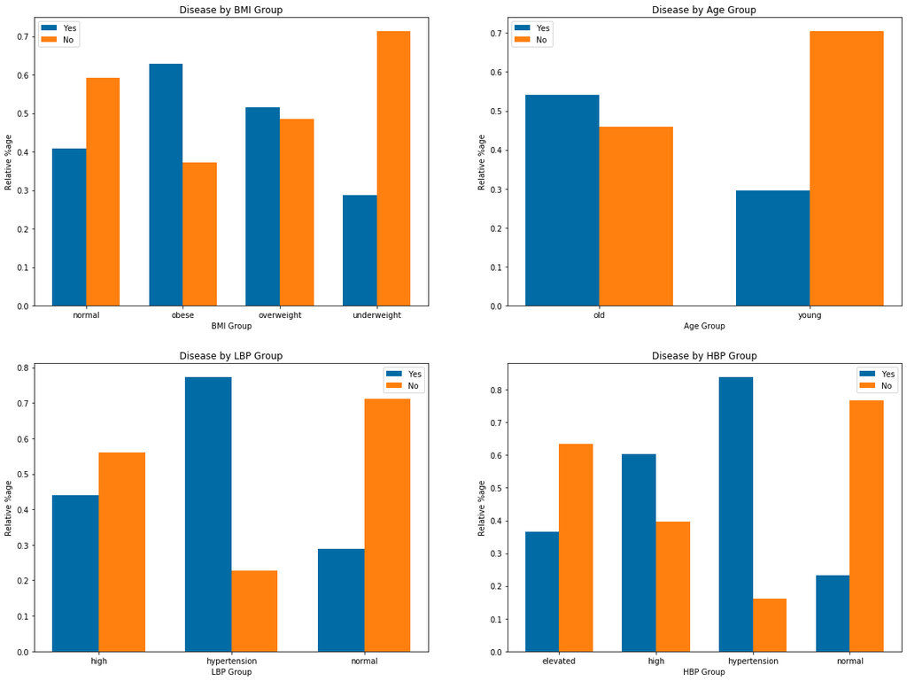

```python
fig = plt.figure(figsize=(20, 15))
outer = gridspec.GridSpec(2, 2, wspace=0.2, hspace=0.2)
col=['BMI Group','Age Group','LBP Group','HBP Group']

for i in range(4):
    ax = plt.Subplot(fig, outer[i])

    dist_data = pd.concat([df[df.Disease == 1].groupby(col[i])[col[i]].count()
                     ,df[df.Disease == 0].groupby(col[i])[col[i]].count()],axis=1)
    col1,col2 = (col[i]+'_Yes'),(col[i]+'_No')
    dist_data.columns = [(col[i]+'_Yes'),(col[i]+'_No')]

    dist_data_Yes = dist_data[col1]/(dist_data[col1]+dist_data[col2])

    dist_data_No = dist_data[col2]/(dist_data[col1]+dist_data[col2])

    x = np.arange(len(dist_data))
    width = 0.35

    mpl.style.use('tableau-colorblind10')
    ax.bar(x - width/2, dist_data_Yes, width, label='Yes')
    ax.bar(x + width/2, dist_data_No, width, label='No')

    ax.set_ylabel('Relative %age')
    ax.set_xlabel(col[i])
    ax.set_title('Disease by '+col[i])
    ax.set_xticks(x)
    ax.set_xticklabels(dist_data.index)
    ax.legend()

    fig.add_subplot(ax)

fig.show()
```

##### We can see that the binned values have high distinguishing factor. This will be helpful for the Naive bayes object to make predictions

```python
X_train, X_test, y_train, y_test = train_test_split(nbc_df,target,test_size=0.3,random_state=123)
```

##### Lets run the models again

##### Running and Checking the performance of the GaussianNB

```python
#Gaussian Naive Bayes
gnb= GaussianNB()
gnb.fit(X_train, y_train)
y_pred = gnb.predict(X_test)

#performance metrics
print("Precision - ",round(metrics.precision_score(y_test,y_pred)*100,2))
print("Accuracy - ",round(metrics.accuracy_score(y_test,y_pred)*100,2))
print("Recall - ",round(metrics.recall_score(y_test,y_pred)*100,2))
print("F1 Score - ",round(metrics.f1_score(y_test,y_pred)*100,2))
```

```
Precision -  72.9
Accuracy -  71.32
Recall -  68.24
F1 Score -  70.49
```

##### Running and Checking the performance of the Bernoulli NB

```python
#Bernoulli Naive Bayes
bnb = BernoulliNB()
bnb.fit(X_train, y_train)
y_pred = bnb.predict(X_test)

#performance metrics
print("Precision - ",round(metrics.precision_score(y_test,y_pred)*100,2))
print("Accuracy - ",round(metrics.accuracy_score(y_test,y_pred)*100,2))
print("Recall - ",round(metrics.recall_score(y_test,y_pred)*100,2))
print("F1 Score - ",round(metrics.f1_score(y_test,y_pred)*100,2))
```

```
Precision -  75.51
Accuracy -  72.18
Recall -  65.97
F1 Score -  70.42
```

##### Running and Checking the performance of the MultinomialNB

```python
#Multinomial Naive Bayes
mnb = MultinomialNB()
mnb.fit(X_train, y_train)
y_pred = mnb.predict(X_test)

#performance metrics
print("Precision - ",round(metrics.precision_score(y_test,y_pred)*100,2))
print("Accuracy - ",round(metrics.accuracy_score(y_test,y_pred)*100,2))
print("Recall - ",round(metrics.recall_score(y_test,y_pred)*100,2))
print("F1 Score - ",round(metrics.f1_score(y_test,y_pred)*100,2))
```

```
Precision -  76.04
Accuracy -  72.25
Recall -  65.3
F1 Score -  70.26
```

##### As you can see, binning data improved the performance of all models. As in the previous case, Multinomial NBC performs the best out of the bunch. Hence we will be using the same to make predictions on the testing data.

##### Lets plot the ROC curve for our final model

##### Since we want to compare model performances, lets make a function to plot ROC for all the models we run so that there is no repitition of code

```python
from sklearn.metrics import roc_curve
from sklearn.metrics import roc_auc_score
def plot_rocs(pred_prob):

    plt.figure(figsize=(8, 6))
    plt.plot([0, 1], [0, 1], 'k--')
    plt.axis([0, 1, 0, 1])

    for model, values in pred_prob.items():
        fpr, tpr, thresholds = roc_curve(values[1],values[0][:,1])
        auc = round(roc_auc_score(values[1],values[0][:,1])*100,2)
        plt.plot(fpr, tpr, linewidth=2, label="%s Classifier : AUC = %0.2f" % (model,auc))

    plt.legend(loc = 'lower right')
    plt.xlabel('False Positive Rate (Fall-Out)', fontsize=16)
    plt.ylabel('True Positive Rate (Recall)', fontsize=16)
    plt.title('ROC Curve for Classifiers ')
    plt.show()
```

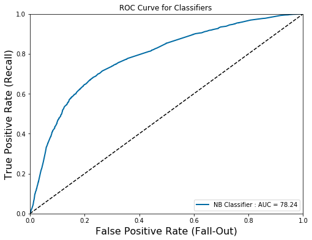

```python
# storing the prediction probabilities in a dictionary for future use

pred_prob={}
pred_prob['NB'] = [mnb.predict_proba(X_test),y_test]

plot_rocs(pred_prob)
```

### b) K Nearest Neighbour Classifier

```python
#creating a new dataframe for KNN
knn_df = df
```

##### Segregating the dependent and the independent variables and transforming the independent variables

```python
target=knn_df['Disease']
knn_df=knn_df.drop(columns=['Disease','Gender'])
```

```python
#creating a pipline to transform the categorical and numerical variables

cat_var=['Smoke','Alcohol','Exercise','Glucose','Cholesterol']
num_var=['Age','BMI','Low Blood Pressure','High Blood Pressure']

pipeline_knn = ColumnTransformer([
        ("num", StandardScaler(), num_var),
        ("cat", OneHotEncoder(sparse=False), cat_var),
    ])
```

```python
# transform the dataframe for the KNN Model

transformed = pipeline_knn.fit_transform(knn_df)
transformed_df_cols = num_var
for i in cat_var:
    v = np.sort(df[i].unique())
    for j in v:
        col=i+'_'+str(j)
        transformed_df_cols.append(col)
df_transformed = pd.DataFrame(transformed,columns=transformed_df_cols)

del knn_df
```

```python
df_transformed.head()
```

|  | Age | BMI | Low Blood Pressure | High Blood Pressure | Smoke_0 | Smoke_1 | Alcohol_0 | Alcohol_1 | Exercise_0 | Exercise_1 | Glucose_high | Glucose_normal | Glucose_too high | Cholesterol_high | Cholesterol_normal | Cholesterol_too high |
| --- | --- | --- | --- | --- | --- | --- | --- | --- | --- | --- | --- | --- | --- | --- | --- | --- |
| 0 | 0.905030 | 0.642077 | -1.262326 | 0.185411 | 1.0 | 0.0 | 1.0 | 0.0 | 0.0 | 1.0 | 0.0 | 1.0 | 0.0 | 0.0 | 1.0 | 0.0 |
| 1 | 1.640956 | 0.642387 | 1.807716 | 0.770597 | 1.0 | 0.0 | 1.0 | 0.0 | 1.0 | 0.0 | 0.0 | 1.0 | 0.0 | 0.0 | 1.0 | 0.0 |
| 2 | -1.744304 | 0.408207 | -1.070448 | -1.570145 | 1.0 | 0.0 | 0.0 | 1.0 | 0.0 | 1.0 | 0.0 | 1.0 | 0.0 | 0.0 | 1.0 | 0.0 |
| 3 | -0.419637 | 1.560571 | -0.111060 | 0.185411 | 0.0 | 1.0 | 1.0 | 0.0 | 0.0 | 1.0 | 0.0 | 1.0 | 0.0 | 0.0 | 1.0 | 0.0 |
| 4 | -2.038674 | -0.714017 | -0.111060 | -0.984960 | 1.0 | 0.0 | 1.0 | 0.0 | 0.0 | 1.0 | 1.0 | 0.0 | 0.0 | 1.0 | 0.0 | 0.0 |

##### Splitting the data to training and testing data

```python
X_train, X_test, y_train, y_test = train_test_split(df_transformed, target, test_size=0.3, random_state=123)
```

##### Now that we have the Train and test data, we can feed this data to the base KNN model

```python
from sklearn.neighbors import KNeighborsClassifier
knn = KNeighborsClassifier(n_jobs=3)
knn.fit(X_train, y_train)
```

```
KNeighborsClassifier(algorithm='auto', leaf_size=30, metric='minkowski',
                     metric_params=None, n_jobs=3, n_neighbors=5, p=2,
                     weights='uniform')
```

##### Checking the performance of the base model

```python
y_pred = knn.predict(X_test)

#performance metrics
print("Precision - ",round(metrics.precision_score(y_test,y_pred)*100,2))
print("Accuracy - ",round(metrics.accuracy_score(y_test,y_pred)*100,2))
print("Recall - ",round(metrics.recall_score(y_test,y_pred)*100,2))
print("F1 Score - ",round(metrics.f1_score(y_test,y_pred)*100,2))
```

```
Precision -  69.53
Accuracy -  69.45
Recall -  69.67
F1 Score -  69.6
```

###### Now that the we have the base model perforn, We will run Grid Search on the model to get the optimal performance

```python
param_grid = {'n_neighbors': list(range(3,50,2)),
              'algorithm': ['auto', 'ball_tree', 'kd_tree', 'brute'],
              'p': [1,2]}

grid = GridSearchCV(knn, param_grid, cv=6, verbose=1, scoring='accuracy', n_jobs=3)
```

```python
#grid.fit(X_train,y_train)
```

```python
#grid.best_score_
```

```python
#grid.best_params_
```

```python
# Running Kmeans again with the optamized hyperparameters

knn_final = KNeighborsClassifier(algorithm='auto',p=1,n_neighbors=40,n_jobs=4)
knn_final.fit(X_train, y_train)
```

```
KNeighborsClassifier(algorithm='auto', leaf_size=30, metric='minkowski',
                     metric_params=None, n_jobs=4, n_neighbors=40, p=1,
                     weights='uniform')
```

```python
y_pred = knn_final.predict(X_test)

#performance metrics
print("Precision - ",round(metrics.precision_score(y_test,y_pred)*100,2))
print("Accuracy - ",round(metrics.accuracy_score(y_test,y_pred)*100,2))
print("Recall - ",round(metrics.recall_score(y_test,y_pred)*100,2))
print("F1 Score - ",round(metrics.f1_score(y_test,y_pred)*100,2))
```

```
Precision -  75.82
Accuracy -  73.37
Recall -  68.94
F1 Score -  72.21
```

##### As you can see, the model has drastically imporved their performance after using the best hyperparameters. We will be using this model to make predictions on our testing file

##### Lets plot the ROC curve for our final KNN model, overlaping with the NBC model

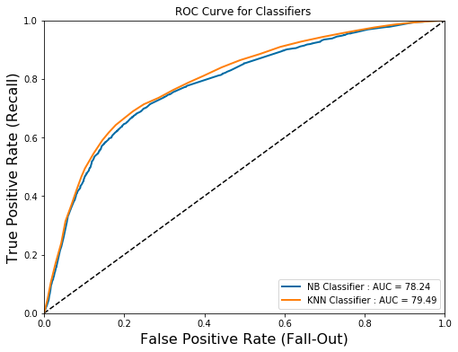

```python
#KNN
pred_prob['KNN'] = [knn_final.predict_proba(X_test),y_test]

plot_rocs(pred_prob)
```

##### Plotting the PCA graph shows how the data has been distirbuted by the KNN object

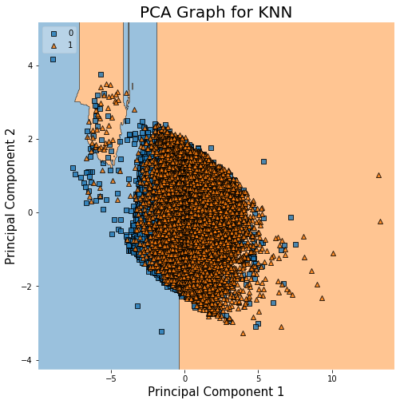

```python
from mlxtend.plotting import plot_decision_regions
from sklearn.decomposition import PCA

knn = KNeighborsClassifier(algorithm='auto',p=1,n_neighbors=40,n_jobs=4)
pca = PCA(n_components = 2)
X_train = pca.fit_transform(X_train)
knn.fit(X_train, y_train)

plt.figure(figsize = (8,8))
plot_decision_regions(X_train, y_train.values, clf=knn, legend=2)

plt.xlabel('Principal Component 1', fontsize = 15)
plt.ylabel('Principal Component 2', fontsize = 15)
plt.title('PCA Graph for KNN', fontsize = 20)
plt.show()
```

### c) Linear Support Vector Machine Classifier

```python
#creating a new dataframe for Linear SVM
lsvm_df = df
```

##### Segregating the dependent and the independent variables and transforming the independent variables

```python
target=lsvm_df['Disease']
lsvm_df=lsvm_df.drop(columns=['Disease','Gender'])
```

```python
# transform the dataframe for the LSVM Model

cat_var=['Smoke','Alcohol','Exercise','Cholesterol','Glucose']
num_var=['Age','BMI','Low Blood Pressure','High Blood Pressure']

pipeline_lsvm = ColumnTransformer([
        ("num", RobustScaler(), num_var),
        ("cat", OneHotEncoder(sparse=False), cat_var),
    ])

transformed = pipeline_lsvm.fit_transform(df)
transformed_df_cols = num_var
for i in cat_var:
    v = np.sort(df[i].unique())
    for j in v:
        col=i+'_'+str(j)
        transformed_df_cols.append(col)
df_transformed = pd.DataFrame(transformed,columns=transformed_df_cols)
```

```python
df_transformed.head()
```

|  | Age | BMI | Low Blood Pressure | High Blood Pressure | Smoke_0 | Smoke_1 | Alcohol_0 | Alcohol_1 | Exercise_0 | Exercise_1 | Cholesterol_high | Cholesterol_normal | Cholesterol_too high | Glucose_high | Glucose_normal | Glucose_too high |
| --- | --- | --- | --- | --- | --- | --- | --- | --- | --- | --- | --- | --- | --- | --- | --- | --- |
| 0 | 0.6 | 0.768449 | -1.2 | 0.5 | 1.0 | 0.0 | 1.0 | 0.0 | 0.0 | 1.0 | 0.0 | 1.0 | 0.0 | 0.0 | 1.0 | 0.0 |
| 1 | 1.1 | 0.768739 | 2.0 | 1.0 | 1.0 | 0.0 | 1.0 | 0.0 | 1.0 | 0.0 | 0.0 | 1.0 | 0.0 | 0.0 | 1.0 | 0.0 |
| 2 | -1.2 | 0.549057 | -1.0 | -1.0 | 1.0 | 0.0 | 0.0 | 1.0 | 0.0 | 1.0 | 0.0 | 1.0 | 0.0 | 0.0 | 1.0 | 0.0 |
| 3 | -0.3 | 1.630078 | 0.0 | 0.5 | 0.0 | 1.0 | 1.0 | 0.0 | 0.0 | 1.0 | 0.0 | 1.0 | 0.0 | 0.0 | 1.0 | 0.0 |
| 4 | -1.4 | -0.503688 | 0.0 | -0.5 | 1.0 | 0.0 | 1.0 | 0.0 | 0.0 | 1.0 | 1.0 | 0.0 | 0.0 | 1.0 | 0.0 | 0.0 |

##### Splitting the data to training and testing data

```python
X_train, X_test, y_train, y_test = train_test_split(df_transformed, target, test_size=0.2, random_state=123)
```

##### Now that we have the Train and test data, we can feed this data to the base Linear SVM model

```python
from sklearn.svm import SVC

lsvm = SVC(kernel='linear')
lsvm.fit(X_train, y_train)
```

```
SVC(C=1.0, cache_size=200, class_weight=None, coef0=0.0,
    decision_function_shape='ovr', degree=3, gamma='auto_deprecated',
    kernel='linear', max_iter=-1, probability=False, random_state=None,
    shrinking=True, tol=0.001, verbose=False)
```

##### Checking the performance of the base model

```python
y_pred = lsvm.predict(X_test)

#performance metrics
print("Precision - ",round(metrics.precision_score(y_test,y_pred)*100,2))
print("Accuracy - ",round(metrics.accuracy_score(y_test,y_pred)*100,2))
print("Recall - ",round(metrics.recall_score(y_test,y_pred)*100,2))
print("F1 Score - ",round(metrics.f1_score(y_test,y_pred)*100,2))
```

```
Precision -  76.39
Accuracy -  72.7
Recall -  65.46
F1 Score -  70.5
```

###### Now that the we have the base model perforn, We will run Grid Search on the model to get the optimal performance

```python
param_grid = {'C': [0.001,0.01,0.1,1.0,10,100,1000]}

grid = GridSearchCV(lsvm, param_grid, cv=6, verbose=0, scoring='accuracy')
```

```python
#grid.fit(X_train,y_train)
```

```python
#grid.best_score_
```

```python
#grid.best_params_
```

```python
# Running Linear SVM again with the optamized hyperparameters

lsvm_final = SVC(kernel='linear',C=10,probability=True)
lsvm_final.fit(X_train, y_train)
```

```
SVC(C=10, cache_size=200, class_weight=None, coef0=0.0,
    decision_function_shape='ovr', degree=3, gamma='auto_deprecated',
    kernel='linear', max_iter=-1, probability=True, random_state=None,
    shrinking=True, tol=0.001, verbose=False)
```

```python
y_pred = lsvm_final.predict(X_test)

#performance metrics
print("Precision - ",round(metrics.precision_score(y_test,y_pred)*100,2))
print("Accuracy - ",round(metrics.accuracy_score(y_test,y_pred)*100,2))
print("Recall - ",round(metrics.recall_score(y_test,y_pred)*100,2))
print("F1 Score - ",round(metrics.f1_score(y_test,y_pred)*100,2))
```

```
Precision -  76.39
Accuracy -  72.7
Recall -  65.46
F1 Score -  70.5
```

##### Lets plot the ROC curve for our final model, overlaping with the previous models

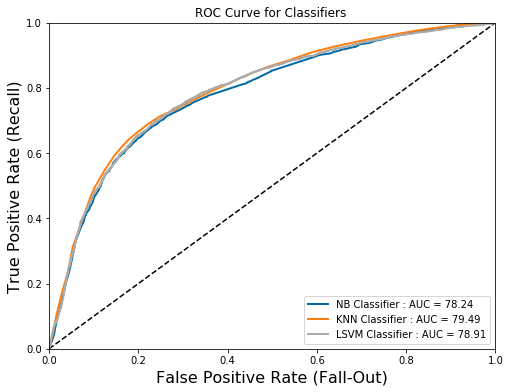

```python
#LSVM

pred_prob['LSVM'] = [lsvm_final.predict_proba(X_test),y_test]

plot_rocs(pred_prob)
```

##### Plotting the PCA graph shows how the data has been distirbuted by the LSVM object

[figure not shown]

```python
lsvm = SVC(kernel='linear',C=10,probability=True)
pca = PCA(n_components = 2)
X_train = pca.fit_transform(X_train)
lsvm.fit(X_train, y_train)

plt.figure(figsize = (8,8))
plot_decision_regions(X_train, y_train.values, clf=lsvm, legend=2)

plt.xlabel('Principal Component 1', fontsize = 15)
plt.ylabel('Principal Component 2', fontsize = 15)
plt.title('PCA Graph for Gaussian SVM', fontsize = 20)
plt.show()
```

### d) Gaussian Support Vector Machine Classifier

```python
#creating a new dataframe for G SVM
gsvm_df = df
```

##### Segregating the dependent and the independent variables and transforming the independent variables

```python
target=gsvm_df['Disease']
gsvm_df=gsvm_df.drop(columns=['Disease','Gender'])
```

```python
# transform the dataframe for the GSVM Model

cat_var=['Smoke','Alcohol','Exercise','Glucose','Cholesterol']
num_var=['Age','BMI','Low Blood Pressure','High Blood Pressure']

pipeline_gsvm = ColumnTransformer([
        ("num", RobustScaler(), num_var),
        ("cat", OneHotEncoder(sparse=False), cat_var),
    ])

transformed = pipeline_gsvm.fit_transform(df)
transformed_df_cols = num_var
for i in cat_var:
    v = np.sort(df[i].unique())
    for j in v:
        col=i+'_'+str(j)
        transformed_df_cols.append(col)
df_transformed = pd.DataFrame(transformed,columns=transformed_df_cols)
```

```python
df_transformed.head()
```

|  | Age | BMI | Low Blood Pressure | High Blood Pressure | Smoke_0 | Smoke_1 | Alcohol_0 | Alcohol_1 | Exercise_0 | Exercise_1 | Glucose_high | Glucose_normal | Glucose_too high | Cholesterol_high | Cholesterol_normal | Cholesterol_too high |
| --- | --- | --- | --- | --- | --- | --- | --- | --- | --- | --- | --- | --- | --- | --- | --- | --- |
| 0 | 0.6 | 0.768449 | -1.2 | 0.5 | 1.0 | 0.0 | 1.0 | 0.0 | 0.0 | 1.0 | 0.0 | 1.0 | 0.0 | 0.0 | 1.0 | 0.0 |
| 1 | 1.1 | 0.768739 | 2.0 | 1.0 | 1.0 | 0.0 | 1.0 | 0.0 | 1.0 | 0.0 | 0.0 | 1.0 | 0.0 | 0.0 | 1.0 | 0.0 |
| 2 | -1.2 | 0.549057 | -1.0 | -1.0 | 1.0 | 0.0 | 0.0 | 1.0 | 0.0 | 1.0 | 0.0 | 1.0 | 0.0 | 0.0 | 1.0 | 0.0 |
| 3 | -0.3 | 1.630078 | 0.0 | 0.5 | 0.0 | 1.0 | 1.0 | 0.0 | 0.0 | 1.0 | 0.0 | 1.0 | 0.0 | 0.0 | 1.0 | 0.0 |
| 4 | -1.4 | -0.503688 | 0.0 | -0.5 | 1.0 | 0.0 | 1.0 | 0.0 | 0.0 | 1.0 | 1.0 | 0.0 | 0.0 | 1.0 | 0.0 | 0.0 |

##### Splitting the data to training and testing data

```python
X_train, X_test, y_train, y_test = train_test_split(df_transformed, target, test_size=0.3, random_state=123)
```

##### Now that we have the Train and test data, we can feed this data to the base Gaussian SVM model

```python
gsvm = SVC(kernel='rbf')
gsvm.fit(X_train, y_train)
```

```
SVC(C=1.0, cache_size=200, class_weight=None, coef0=0.0,
    decision_function_shape='ovr', degree=3, gamma='auto_deprecated',
    kernel='rbf', max_iter=-1, probability=False, random_state=None,
    shrinking=True, tol=0.001, verbose=False)
```

##### Checking the performance of the base model

```python
y_pred = gsvm.predict(X_test)

#performance metrics
print("Precision - ",round(metrics.precision_score(y_test,y_pred)*100,2))
print("Accuracy - ",round(metrics.accuracy_score(y_test,y_pred)*100,2))
print("Recall - ",round(metrics.recall_score(y_test,y_pred)*100,2))
print("F1 Score - ",round(metrics.f1_score(y_test,y_pred)*100,2))
```

```
Precision -  76.81
Accuracy -  73.61
Recall -  67.95
F1 Score -  72.11
```

###### Now that the we have the base model perforn, We will run Grid Search on the model to get the optimal performance

```python
C_range = np.logspace(-4, 8, 13)
gamma_range = np.logspace(-9, 3, 13)

param_grid = {'C': C_range,
             'gamma':gamma_range }

grid = GridSearchCV(lsvm, param_grid, cv=6, verbose=0, scoring='accuracy')
```

```python
#grid.fit(X_train,y_train)
```

```python
#grid.best_score_
```

```python
#grid.best_params_
```

```python
# Running Gaussian SVM again with the optamized hyperparameters

gsvm_final = SVC(kernel='rbf', C=1, gamma=0.1,probability=True)
gsvm_final.fit(X_train, y_train)
```

```
SVC(C=1, cache_size=200, class_weight=None, coef0=0.0,
    decision_function_shape='ovr', degree=3, gamma=0.1, kernel='rbf',
    max_iter=-1, probability=True, random_state=None, shrinking=True, tol=0.001,
    verbose=False)
```

```python
y_pred = gsvm_final.predict(X_test)

#performance metrics
print("Precision - ",round(metrics.precision_score(y_test,y_pred)*100,2))
print("Accuracy - ",round(metrics.accuracy_score(y_test,y_pred)*100,2))
print("Recall - ",round(metrics.recall_score(y_test,y_pred)*100,2))
print("F1 Score - ",round(metrics.f1_score(y_test,y_pred)*100,2))
```

```
Precision -  77.06
Accuracy -  73.73
Recall -  67.88
F1 Score -  72.18
```

##### Lets plot the ROC curve for our final model, overlaping with the previous models

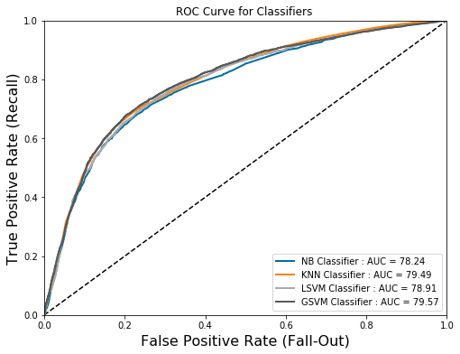

```python
#GSVM
pred_prob['GSVM'] = [gsvm_final.predict_proba(X_test),y_test]

plot_rocs(pred_prob)
```

##### Plotting the PCA graph shows how the data has been distirbuted by the GSVM object

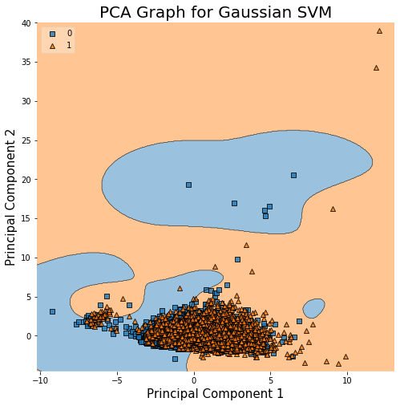

```python
gsvm= SVC(kernel='rbf', C=1, gamma=0.1,probability=True)
pca = PCA(n_components = 2)
X_train = pca.fit_transform(X_train)
gsvm.fit(X_train, y_train)

plt.figure(figsize = (8,8))
plot_decision_regions(X_train, y_train.values, clf=gsvm, legend=2)

plt.xlabel('Principal Component 1', fontsize = 15)
plt.ylabel('Principal Component 2', fontsize = 15)
plt.title('PCA Graph for Gaussian SVM', fontsize = 20)
plt.show()
```

### e) Random Forest Classifier

```python
#creating a new dataframe for Random forest
rf_df = df
```

##### Segregating the dependent and the independent variables and transforming the independent variables

```python
target=rf_df['Disease']
rf_df=rf_df.drop(columns=['Disease','Height','Weight','Gender','BMI Group','Age Group','LBP Group','HBP Group'])
rf_df = pd.get_dummies(rf_df,columns=['Smoke','Alcohol','Exercise','Glucose','Cholesterol'])
```

```python
rf_df.head()
```

|  | Age | High Blood Pressure | Low Blood Pressure | BMI | Smoke_0 | Smoke_1 | Alcohol_0 | Alcohol_1 | Exercise_0 | Exercise_1 | Glucose_high | Glucose_normal | Glucose_too high | Cholesterol_high | Cholesterol_normal | Cholesterol_too high |
| --- | --- | --- | --- | --- | --- | --- | --- | --- | --- | --- | --- | --- | --- | --- | --- | --- |
| 0 | 59 | 130 | 68 | 31.553659 | 1 | 0 | 1 | 0 | 0 | 1 | 0 | 1 | 0 | 0 | 1 | 0 |
| 1 | 64 | 140 | 100 | 31.555556 | 1 | 0 | 1 | 0 | 1 | 0 | 0 | 1 | 0 | 0 | 1 | 0 |
| 2 | 41 | 100 | 70 | 30.120482 | 1 | 0 | 0 | 1 | 0 | 1 | 0 | 1 | 0 | 0 | 1 | 0 |
| 3 | 50 | 130 | 80 | 37.182261 | 0 | 1 | 1 | 0 | 0 | 1 | 0 | 1 | 0 | 0 | 1 | 0 |
| 4 | 39 | 110 | 80 | 23.243408 | 1 | 0 | 1 | 0 | 0 | 1 | 1 | 0 | 0 | 1 | 0 | 0 |

##### Splitting the data to training and testing data

```python
X_train, X_test, y_train, y_test = train_test_split(rf_df, target, test_size=0.3, random_state=123)
```

##### Now that we have the Train and test data, we can feed this data to the base Random Forest model

```python
from sklearn.ensemble import RandomForestClassifier

rf = RandomForestClassifier()
rf.fit(X_train,y_train)
```

```
RandomForestClassifier(bootstrap=True, class_weight=None, criterion='gini',
                       max_depth=None, max_features='auto', max_leaf_nodes=None,
                       min_impurity_decrease=0.0, min_impurity_split=None,
                       min_samples_leaf=1, min_samples_split=2,
                       min_weight_fraction_leaf=0.0, n_estimators=10,
                       n_jobs=None, oob_score=False, random_state=None,
                       verbose=0, warm_start=False)
```

##### Checking the performance of the base model

```python
y_pred = rf.predict(X_test)

#performance metrics
print("Precision - ",round(metrics.precision_score(y_test,y_pred)*100,2))
print("Accuracy - ",round(metrics.accuracy_score(y_test,y_pred)*100,2))
print("Recall - ",round(metrics.recall_score(y_test,y_pred)*100,2))
print("F1 Score - ",round(metrics.f1_score(y_test,y_pred)*100,2))
```

```
Precision -  67.38
Accuracy -  66.91
Recall -  66.06
F1 Score -  66.71
```

###### Now that the we have the base model perforn, We will run Grid Search on the model to get the optimal performance

```python
param_grid = {'n_estimators':list(range(50,1001,50)),
             'criterion': ['gini', 'entropy'],
                'max_depth': [5,10,15,20,25,30],
             'min_samples_split': list(range(2,11)),
             'min_samples_leaf': [1,5,10,15,20,25,30],
             'max_features': list(range(1,nbc_df.shape[1]+1))}

grid = GridSearchCV(rf, param_grid, cv=6, verbose=0, scoring='accuracy')
```

```python
#grid.fit(X_train,y_train)
```

```python
#grid.best_score_
```

```python
#grid.best_params_
```

```python
# Running Random Forest again with the optamized hyperparameters

rf_final = RandomForestClassifier(n_estimators=350,criterion='gini',max_depth=10,min_samples_split=10,min_samples_leaf=30, max_features=11,random_state=None)
rf_final.fit(X_train,y_train)
```

```
RandomForestClassifier(bootstrap=True, class_weight=None, criterion='gini',
                       max_depth=10, max_features=11, max_leaf_nodes=None,
                       min_impurity_decrease=0.0, min_impurity_split=None,
                       min_samples_leaf=30, min_samples_split=10,
                       min_weight_fraction_leaf=0.0, n_estimators=350,
                       n_jobs=None, oob_score=False, random_state=None,
                       verbose=0, warm_start=False)
```

```python
y_pred = rf_final.predict(X_test)

#performance metrics
print("Precision - ",round(metrics.precision_score(y_test,y_pred)*100,2))
print("Accuracy - ",round(metrics.accuracy_score(y_test,y_pred)*100,2))
print("Recall - ",round(metrics.recall_score(y_test,y_pred)*100,2))
print("F1 Score - ",round(metrics.f1_score(y_test,y_pred)*100,2))
```

```
Precision -  75.83
Accuracy -  73.6
Recall -  69.58
F1 Score -  72.57
```

##### As you can see, the model has imporved their performance by drastically after using the best hyperparameters. We will be using this model to make predictions on our testing file

##### Lets plot the ROC curve for our final model, overlaping with the previous models

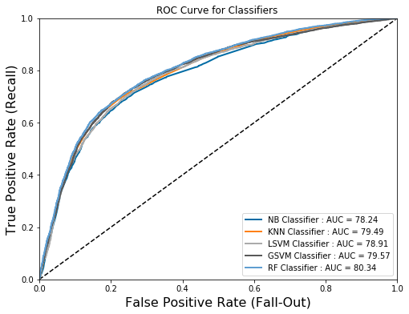

```python
#RF
pred_prob['RF'] = [rf_final.predict_proba(X_test),y_test]

plot_rocs(pred_prob)
```

##### Plotting the important features in the final model

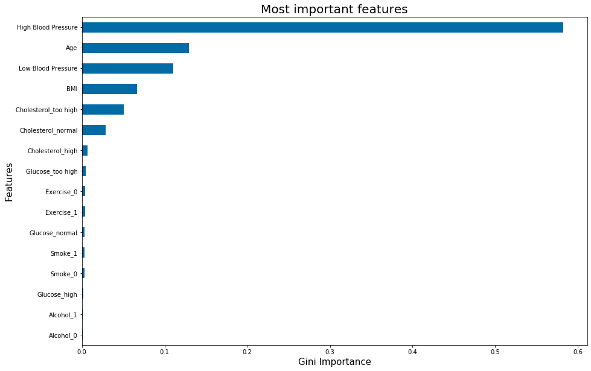

```python
model_ranks = pd.Series(rf_final.feature_importances_, index=X_train.columns, name='Importance')
model_ranks.sort_values(ascending=True,inplace=True)
top_features = model_ranks[-26:]
plt.figure(figsize=(15,10))
ax = top_features.plot(kind='barh')
ax.set_xlabel('Gini Importance', fontsize = 15)
ax.set_ylabel('Features', fontsize = 15)
ax.set_title('Most important features', fontsize = 20)
plt.show();
```

##### Plotting the PCA graph shows how the data has been distirbuted by the Random Forest object

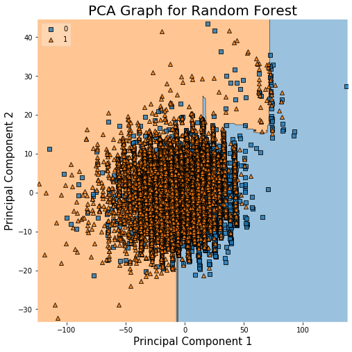

```python
rf= RandomForestClassifier(n_estimators=350,criterion='gini',max_depth=10,min_samples_split=10,min_samples_leaf=30, max_features=2,random_state=None)
pca = PCA(n_components = 2)
X_train = pca.fit_transform(X_train)
rf.fit(X_train, y_train)

plt.figure(figsize = (8,8))
plot_decision_regions(X_train, y_train.values, clf=rf, legend=2)

plt.xlabel('Principal Component 1', fontsize = 15)
plt.ylabel('Principal Component 2', fontsize = 15)
plt.title('PCA Graph for Random Forest', fontsize = 20)
plt.show()
```

### f) Gradient Boosting Classifier

```python
#creating a new dataframe for Random forest
gbc_df = df
```

##### Segregating the dependent and the independent variables and transforming the independent variables

```python
target=gbc_df['Disease']
gbc_df=gbc_df.drop(columns=['Disease','Height','Weight','Gender','BMI Group','Age Group','LBP Group','HBP Group'])
gbc_df = pd.get_dummies(gbc_df,columns=['Smoke','Alcohol','Exercise','Glucose','Cholesterol'])
```

```python
gbc_df.head()
```

|  | Age | High Blood Pressure | Low Blood Pressure | BMI | Smoke_0 | Smoke_1 | Alcohol_0 | Alcohol_1 | Exercise_0 | Exercise_1 | Glucose_high | Glucose_normal | Glucose_too high | Cholesterol_high | Cholesterol_normal | Cholesterol_too high |
| --- | --- | --- | --- | --- | --- | --- | --- | --- | --- | --- | --- | --- | --- | --- | --- | --- |
| 0 | 59 | 130 | 68 | 31.553659 | 1 | 0 | 1 | 0 | 0 | 1 | 0 | 1 | 0 | 0 | 1 | 0 |
| 1 | 64 | 140 | 100 | 31.555556 | 1 | 0 | 1 | 0 | 1 | 0 | 0 | 1 | 0 | 0 | 1 | 0 |
| 2 | 41 | 100 | 70 | 30.120482 | 1 | 0 | 0 | 1 | 0 | 1 | 0 | 1 | 0 | 0 | 1 | 0 |
| 3 | 50 | 130 | 80 | 37.182261 | 0 | 1 | 1 | 0 | 0 | 1 | 0 | 1 | 0 | 0 | 1 | 0 |
| 4 | 39 | 110 | 80 | 23.243408 | 1 | 0 | 1 | 0 | 0 | 1 | 1 | 0 | 0 | 1 | 0 | 0 |

##### Splitting the data to training and testing data

```python
X_train, X_test, y_train, y_test = train_test_split(gbc_df, target, test_size=0.3, random_state=123)
```

```python
from sklearn.ensemble import GradientBoostingClassifier

gbc = GradientBoostingClassifier()
gbc.fit(X_train, y_train)
```

```
GradientBoostingClassifier(criterion='friedman_mse', init=None,
                           learning_rate=0.1, loss='deviance', max_depth=3,
                           max_features=None, max_leaf_nodes=None,
                           min_impurity_decrease=0.0, min_impurity_split=None,
                           min_samples_leaf=1, min_samples_split=2,
                           min_weight_fraction_leaf=0.0, n_estimators=100,
                           n_iter_no_change=None, presort='auto',
                           random_state=None, subsample=1.0, tol=0.0001,
                           validation_fraction=0.1, verbose=0,
                           warm_start=False)
```

##### Checking the performance of the base model

```python
y_pred = gbc.predict(X_test)

#performance metrics
print("Precision - ",round(metrics.precision_score(y_test,y_pred)*100,2))
print("Accuracy - ",round(metrics.accuracy_score(y_test,y_pred)*100,2))
print("Recall - ",round(metrics.recall_score(y_test,y_pred)*100,2))
print("F1 Score - ",round(metrics.f1_score(y_test,y_pred)*100,2))
```

```
Precision -  75.7
Accuracy -  73.99
Recall -  70.98
F1 Score -  73.26
```

###### Now that the we have the base model perforn, We will run Grid Search on the model to get the optimal performance

```python
param_grid = {'n_estimators':list(range(100,2000,100)),
              'learning_rate':[0.15,0.1,0.05,0.01,0.005,0.001],
              'min_samples_split': [2],
              'max_depth': list(range(3,20,2)),
              'max_features': list(range(1,gbc_df.shape[1]+1)),
              'subsample':[0.7,0.75,0.8,0.85,0.9,0.95,1]
             }

grid = GridSearchCV(rf, param_grid, cv=6, verbose=0, scoring='accuracy')
```

```python
#grid.fit(X_train,y_train)
```

```python
#grid.best_score_
```

```python
#grid.best_params_
```

```python
# Running Gradient Boosting Classifier again with the optamized hyperparameters

gbc_final = GradientBoostingClassifier(learning_rate=0.1,n_estimators=100, max_depth=3, min_samples_split=2 ,max_features=9)
gbc_final.fit(X_train, y_train)
```

```
GradientBoostingClassifier(criterion='friedman_mse', init=None,
                           learning_rate=0.1, loss='deviance', max_depth=3,
                           max_features=9, max_leaf_nodes=None,
                           min_impurity_decrease=0.0, min_impurity_split=None,
                           min_samples_leaf=1, min_samples_split=2,
                           min_weight_fraction_leaf=0.0, n_estimators=100,
                           n_iter_no_change=None, presort='auto',
                           random_state=None, subsample=1.0, tol=0.0001,
                           validation_fraction=0.1, verbose=0,
                           warm_start=False)
```

```python
y_pred = gbc_final.predict(X_test)

#performance metrics
print("Precision - ",round(metrics.precision_score(y_test,y_pred)*100,2))
print("Accuracy - ",round(metrics.accuracy_score(y_test,y_pred)*100,2))
print("Recall - ",round(metrics.recall_score(y_test,y_pred)*100,2))
print("F1 Score - ",round(metrics.f1_score(y_test,y_pred)*100,2))
```

```
Precision -  75.72
Accuracy -  73.85
Recall -  70.51
F1 Score -  73.02
```

##### Lets plot the ROC curve for our final model, overlaping with the previous models

##### Plotting the important features in the final model

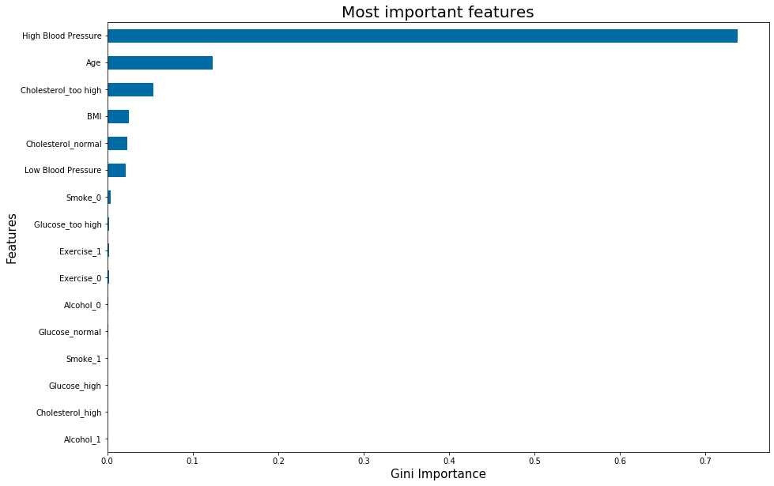

```python
model_ranks = pd.Series(gbc.feature_importances_, index=X_train.columns, name='Importance')
model_ranks.sort_values(ascending=True,inplace=True)
top_features = model_ranks[-26:]
plt.figure(figsize=(15,10))
ax = top_features.plot(kind='barh')
ax.set_xlabel('Gini Importance', fontsize = 15)
ax.set_ylabel('Features', fontsize = 15)
ax.set_title('Most important features', fontsize = 20)
plt.show();
```

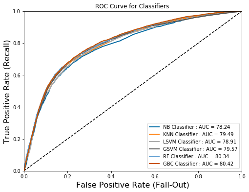

```python
#GBC
pred_prob['GBC'] = [gbc.predict_proba(X_test),y_test]

plot_rocs(pred_prob)
```

## Step 3: Predictions and Interpretations

```python
test = pd.read_csv('Disease Prediction Testing(1).csv')
test.head()
```

|  | ID | Age | Gender | Height | Weight | High Blood Pressure | Low Blood Pressure | Cholesterol | Glucose | Smoke | Alcohol | Exercise |
| --- | --- | --- | --- | --- | --- | --- | --- | --- | --- | --- | --- | --- |
| 0 | 0 | 44 | female | 160 | 59.0 | 100 | 80 | high | normal | 0 | 0 | 1 |
| 1 | 1 | 41 | female | 169 | 74.0 | 120 | 70 | normal | normal | 0 | 0 | 1 |
| 2 | 2 | 63 | male | 168 | 84.0 | 120 | 80 | normal | high | 0 | 0 | 1 |
| 3 | 3 | 55 | female | 158 | 108.0 | 160 | 100 | normal | normal | 0 | 0 | 0 |
| 4 | 4 | 55 | female | 167 | 67.0 | 120 | 80 | normal | normal | 0 | 0 | 1 |

##### Since we dont need Gender and ID columns, we can drop them

```python
test=test.drop(columns=['ID','Gender'])
test.head()
```

|  | Age | Height | Weight | High Blood Pressure | Low Blood Pressure | Cholesterol | Glucose | Smoke | Alcohol | Exercise |
| --- | --- | --- | --- | --- | --- | --- | --- | --- | --- | --- |
| 0 | 44 | 160 | 59.0 | 100 | 80 | high | normal | 0 | 0 | 1 |
| 1 | 41 | 169 | 74.0 | 120 | 70 | normal | normal | 0 | 0 | 1 |
| 2 | 63 | 168 | 84.0 | 120 | 80 | normal | high | 0 | 0 | 1 |
| 3 | 55 | 158 | 108.0 | 160 | 100 | normal | normal | 0 | 0 | 0 |
| 4 | 55 | 167 | 67.0 | 120 | 80 | normal | normal | 0 | 0 | 1 |

#### Checking the shape

```python
test.shape
```

```
(21000, 10)
```

##### Checking for missing values

```python
(test.isnull().sum()/test.shape[0])*100
```

```
Age                    0.0
Height                 0.0
Weight                 0.0
High Blood Pressure    0.0
Low Blood Pressure     0.0
Cholesterol            0.0
Glucose                0.0
Smoke                  0.0
Alcohol                0.0
Exercise               0.0
dtype: float64
```

##### Checking for cases where Low Blood Pressure is high than High Blood Pressure

```python
test[test['Low Blood Pressure']>test['High Blood Pressure']].shape
```

```
(369, 10)
```

##### Swapping

```python
test.loc[test['Low Blood Pressure']>test['High Blood Pressure'],['Low Blood Pressure','High Blood Pressure']] = test.loc[test['Low Blood Pressure']>test['High Blood Pressure'],['High Blood Pressure','Low Blood Pressure']].values
test[test['Low Blood Pressure']>test['High Blood Pressure']].shape[0]
```

```
0
```

###### Checking for negative values

```python
test[test['High Blood Pressure']<0]
```

|  | Age | Height | Weight | High Blood Pressure | Low Blood Pressure | Cholesterol | Glucose | Smoke | Alcohol | Exercise |
| --- | --- | --- | --- | --- | --- | --- | --- | --- | --- | --- |

```python
test[test['Low Blood Pressure']<0]
```

|  | Age | Height | Weight | High Blood Pressure | Low Blood Pressure | Cholesterol | Glucose | Smoke | Alcohol | Exercise |
| --- | --- | --- | --- | --- | --- | --- | --- | --- | --- | --- |
| 4004 | 61 | 167 | 74.0 | 15 | -70 | normal | normal | 0 | 0 | 1 |

##### Converting

```python
test.loc[test['Low Blood Pressure']<0,'Low Blood Pressure']=test[test['Low Blood Pressure']<0]['Low Blood Pressure'].apply(lambda x: abs(x))
test[test['Low Blood Pressure']<0]
```

|  | Age | Height | Weight | High Blood Pressure | Low Blood Pressure | Cholesterol | Glucose | Smoke | Alcohol | Exercise |
| --- | --- | --- | --- | --- | --- | --- | --- | --- | --- | --- |

##### Checking for rows where the blood pressure is greater than the maximum recorded values

```python
test[(test['Low Blood Pressure']>360) | (test['High Blood Pressure']>370)].shape[0]
```

```
306
```

###### Setting these ouliers with the maximum values

```python
test.loc[(test['High Blood Pressure']>360),'High Blood Pressure'] = 370
test.loc[(test['Low Blood Pressure']>360),'Low Blood Pressure'] = 360
```

```python
test[(test['Low Blood Pressure']>360) | (test['High Blood Pressure']>370)].shape[0]
```

```
0
```

##### Getting the BMI for each row

```python
# Calculating BMI
test['BMI']=test['Weight']/((test['Height']*test['Height'])/10000)
```

```python
test.head()
```

|  | Age | Height | Weight | High Blood Pressure | Low Blood Pressure | Cholesterol | Glucose | Smoke | Alcohol | Exercise | BMI |
| --- | --- | --- | --- | --- | --- | --- | --- | --- | --- | --- | --- |
| 0 | 44 | 160 | 59.0 | 100 | 80 | high | normal | 0 | 0 | 1 | 23.046875 |
| 1 | 41 | 169 | 74.0 | 120 | 70 | normal | normal | 0 | 0 | 1 | 25.909457 |
| 2 | 63 | 168 | 84.0 | 120 | 80 | normal | high | 0 | 0 | 1 | 29.761905 |
| 3 | 55 | 158 | 108.0 | 160 | 100 | normal | normal | 0 | 0 | 0 | 43.262298 |
| 4 | 55 | 167 | 67.0 | 120 | 80 | normal | normal | 0 | 0 | 1 | 24.023809 |

##### Now that our data set is ready, we can run our models on it

```python
predictions = pd.DataFrame(columns=['NBC','KNN','LSVM','GSVM','RF','GBC'])
```

### a) Naive Bayes Classifier

##### Binning the data

```python
test_nbc = test
test_nbc['BMI Group'] = test_nbc.BMI.apply(lambda x: BMI(x))
test_nbc['Age Group'] = test_nbc.Age.apply(lambda x: Age_Group(x))
test_nbc['LBP Group'] = test_nbc['Low Blood Pressure'].apply(lambda x: LowBP_Group(x))
test_nbc['HBP Group'] = test_nbc['High Blood Pressure'].apply(lambda x: HighBP_Group(x))
```

##### Transforming the data

```python
test_nbc=test_nbc.drop(columns=['Age','BMI','Height','Weight','Low Blood Pressure','High Blood Pressure'])
test_nbc = pd.get_dummies(test_nbc,columns=['Smoke','Alcohol','Exercise','Glucose','Cholesterol','BMI Group','Age Group','LBP Group','HBP Group'])
test_nbc.head()
```

|  | Smoke_0 | Smoke_1 | Alcohol_0 | Alcohol_1 | Exercise_0 | Exercise_1 | Glucose_high | Glucose_normal | Glucose_too high | Cholesterol_high | ... | BMI Group_underweight | Age Group_old | Age Group_young | LBP Group_high | LBP Group_hypertension | LBP Group_normal | HBP Group_elevated | HBP Group_high | HBP Group_hypertension | HBP Group_normal |
| --- | --- | --- | --- | --- | --- | --- | --- | --- | --- | --- | --- | --- | --- | --- | --- | --- | --- | --- | --- | --- | --- |
| 0 | 1 | 0 | 1 | 0 | 0 | 1 | 0 | 1 | 0 | 1 | ... | 0 | 0 | 1 | 1 | 0 | 0 | 0 | 0 | 0 | 1 |
| 1 | 1 | 0 | 1 | 0 | 0 | 1 | 0 | 1 | 0 | 0 | ... | 0 | 0 | 1 | 0 | 0 | 1 | 1 | 0 | 0 | 0 |
| 2 | 1 | 0 | 1 | 0 | 0 | 1 | 1 | 0 | 0 | 0 | ... | 0 | 1 | 0 | 1 | 0 | 0 | 1 | 0 | 0 | 0 |
| 3 | 1 | 0 | 1 | 0 | 1 | 0 | 0 | 1 | 0 | 0 | ... | 0 | 1 | 0 | 0 | 1 | 0 | 0 | 0 | 1 | 0 |
| 4 | 1 | 0 | 1 | 0 | 0 | 1 | 0 | 1 | 0 | 0 | ... | 0 | 1 | 0 | 1 | 0 | 0 | 1 | 0 | 0 | 0 |

5 rows × 25 columns

###### Storing the Predictions in dataframe

```python
predictions['NBC']=mnb.predict(test_nbc)
```

### b) K Nearest Neighbour Classifier

```python
test_knn = test
```

##### Binning and transforming the data

```python
#creating a pipline to transform the categorical and numerical variables

cat_var=['Smoke','Alcohol','Exercise','Glucose','Cholesterol']
num_var=['Age','BMI','Low Blood Pressure','High Blood Pressure']

pipeline_knn = ColumnTransformer([
        ("num", StandardScaler(), num_var),
        ("cat", OneHotEncoder(sparse=False), cat_var),
    ])
```

```python
# transform the dataframe for the KNN Model

transformed = pipeline_knn.fit_transform(test_knn)
transformed_df_cols = num_var
for i in cat_var:
    v = np.sort(df[i].unique())
    for j in v:
        col=i+'_'+str(j)
        transformed_df_cols.append(col)
df_transformed = pd.DataFrame(transformed,columns=transformed_df_cols)

del test_knn
```

```python
df_transformed.head()
```

|  | Age | BMI | Low Blood Pressure | High Blood Pressure | Smoke_0 | Smoke_1 | Alcohol_0 | Alcohol_1 | Exercise_0 | Exercise_1 | Glucose_high | Glucose_normal | Glucose_too high | Cholesterol_high | Cholesterol_normal | Cholesterol_too high |
| --- | --- | --- | --- | --- | --- | --- | --- | --- | --- | --- | --- | --- | --- | --- | --- | --- |
| 0 | -1.300482 | -0.736030 | -0.154229 | -0.891845 | 1.0 | 0.0 | 1.0 | 0.0 | 0.0 | 1.0 | 0.0 | 1.0 | 0.0 | 1.0 | 0.0 | 0.0 |
| 1 | -1.743265 | -0.270377 | -0.892975 | -0.298234 | 1.0 | 0.0 | 1.0 | 0.0 | 0.0 | 1.0 | 0.0 | 1.0 | 0.0 | 0.0 | 1.0 | 0.0 |
| 2 | 1.503811 | 0.356295 | -0.154229 | -0.298234 | 1.0 | 0.0 | 1.0 | 0.0 | 0.0 | 1.0 | 1.0 | 0.0 | 0.0 | 0.0 | 1.0 | 0.0 |
| 3 | 0.323056 | 2.552385 | 1.323262 | 0.888987 | 1.0 | 0.0 | 1.0 | 0.0 | 1.0 | 0.0 | 0.0 | 1.0 | 0.0 | 0.0 | 1.0 | 0.0 |
| 4 | 0.323056 | -0.577113 | -0.154229 | -0.298234 | 1.0 | 0.0 | 1.0 | 0.0 | 0.0 | 1.0 | 0.0 | 1.0 | 0.0 | 0.0 | 1.0 | 0.0 |

###### Storing the Predictions in dataframe

```python
predictions['KNN']=knn_final.predict(df_transformed)
```

### c) Linear Support Vector Machine Classifier

```python
test_lsvm = test
```

##### Binning and transforming the data

```python
# transform the dataframe for the LSVM Model

cat_var=['Smoke','Alcohol','Exercise','Cholesterol','Glucose']
num_var=['Age','BMI','Low Blood Pressure','High Blood Pressure']

pipeline_lsvm = ColumnTransformer([
        ("num", RobustScaler(), num_var),
        ("cat", OneHotEncoder(sparse=False), cat_var),
    ])

transformed = pipeline_lsvm.fit_transform(test_lsvm)
transformed_df_cols = num_var
for i in cat_var:
    v = np.sort(df[i].unique())
    for j in v:
        col=i+'_'+str(j)
        transformed_df_cols.append(col)
df_transformed = pd.DataFrame(transformed,columns=transformed_df_cols)
```

```python
df_transformed.head()
```

|  | Age | BMI | Low Blood Pressure | High Blood Pressure | Smoke_0 | Smoke_1 | Alcohol_0 | Alcohol_1 | Exercise_0 | Exercise_1 | Cholesterol_high | Cholesterol_normal | Cholesterol_too high | Glucose_high | Glucose_normal | Glucose_too high |
| --- | --- | --- | --- | --- | --- | --- | --- | --- | --- | --- | --- | --- | --- | --- | --- | --- |
| 0 | -0.9 | -0.513746 | 0.0 | -1.0 | 1.0 | 0.0 | 1.0 | 0.0 | 0.0 | 1.0 | 1.0 | 0.0 | 0.0 | 0.0 | 1.0 | 0.0 |
| 1 | -1.2 | -0.068046 | -1.0 | 0.0 | 1.0 | 0.0 | 1.0 | 0.0 | 0.0 | 1.0 | 0.0 | 1.0 | 0.0 | 0.0 | 1.0 | 0.0 |
| 2 | 1.0 | 0.531774 | 0.0 | 0.0 | 1.0 | 0.0 | 1.0 | 0.0 | 0.0 | 1.0 | 0.0 | 1.0 | 0.0 | 1.0 | 0.0 | 0.0 |
| 3 | 0.2 | 2.633765 | 2.0 | 2.0 | 1.0 | 0.0 | 1.0 | 0.0 | 1.0 | 0.0 | 0.0 | 1.0 | 0.0 | 0.0 | 1.0 | 0.0 |
| 4 | 0.2 | -0.361639 | 0.0 | 0.0 | 1.0 | 0.0 | 1.0 | 0.0 | 0.0 | 1.0 | 0.0 | 1.0 | 0.0 | 0.0 | 1.0 | 0.0 |

###### Storing the Predictions in dataframe

```python
predictions['LSVM']=lsvm_final.predict(df_transformed)
```

### d) Gaussian Support Vector Machine Classifier

```python
df_transformed.head()
```

|  | Age | BMI | Low Blood Pressure | High Blood Pressure | Smoke_0 | Smoke_1 | Alcohol_0 | Alcohol_1 | Exercise_0 | Exercise_1 | Cholesterol_high | Cholesterol_normal | Cholesterol_too high | Glucose_high | Glucose_normal | Glucose_too high |
| --- | --- | --- | --- | --- | --- | --- | --- | --- | --- | --- | --- | --- | --- | --- | --- | --- |
| 0 | -0.9 | -0.513746 | 0.0 | -1.0 | 1.0 | 0.0 | 1.0 | 0.0 | 0.0 | 1.0 | 1.0 | 0.0 | 0.0 | 0.0 | 1.0 | 0.0 |
| 1 | -1.2 | -0.068046 | -1.0 | 0.0 | 1.0 | 0.0 | 1.0 | 0.0 | 0.0 | 1.0 | 0.0 | 1.0 | 0.0 | 0.0 | 1.0 | 0.0 |
| 2 | 1.0 | 0.531774 | 0.0 | 0.0 | 1.0 | 0.0 | 1.0 | 0.0 | 0.0 | 1.0 | 0.0 | 1.0 | 0.0 | 1.0 | 0.0 | 0.0 |
| 3 | 0.2 | 2.633765 | 2.0 | 2.0 | 1.0 | 0.0 | 1.0 | 0.0 | 1.0 | 0.0 | 0.0 | 1.0 | 0.0 | 0.0 | 1.0 | 0.0 |
| 4 | 0.2 | -0.361639 | 0.0 | 0.0 | 1.0 | 0.0 | 1.0 | 0.0 | 0.0 | 1.0 | 0.0 | 1.0 | 0.0 | 0.0 | 1.0 | 0.0 |

###### Storing the Predictions in dataframe

```python
predictions['GSVM']=gsvm_final.predict(df_transformed)
```

### e) Random Forest Classifier

```python
test_rf = test
test_rf =test_rf.drop(columns=['Height','Weight','BMI Group','Age Group','LBP Group','HBP Group'])
test_rf  = pd.get_dummies(test_rf ,columns=['Smoke','Alcohol','Exercise','Glucose','Cholesterol'])
test_rf.head()
```

|  | Age | High Blood Pressure | Low Blood Pressure | BMI | Smoke_0 | Smoke_1 | Alcohol_0 | Alcohol_1 | Exercise_0 | Exercise_1 | Glucose_high | Glucose_normal | Glucose_too high | Cholesterol_high | Cholesterol_normal | Cholesterol_too high |
| --- | --- | --- | --- | --- | --- | --- | --- | --- | --- | --- | --- | --- | --- | --- | --- | --- |
| 0 | 44 | 100 | 80 | 23.046875 | 1 | 0 | 1 | 0 | 0 | 1 | 0 | 1 | 0 | 1 | 0 | 0 |
| 1 | 41 | 120 | 70 | 25.909457 | 1 | 0 | 1 | 0 | 0 | 1 | 0 | 1 | 0 | 0 | 1 | 0 |
| 2 | 63 | 120 | 80 | 29.761905 | 1 | 0 | 1 | 0 | 0 | 1 | 1 | 0 | 0 | 0 | 1 | 0 |
| 3 | 55 | 160 | 100 | 43.262298 | 1 | 0 | 1 | 0 | 1 | 0 | 0 | 1 | 0 | 0 | 1 | 0 |
| 4 | 55 | 120 | 80 | 24.023809 | 1 | 0 | 1 | 0 | 0 | 1 | 0 | 1 | 0 | 0 | 1 | 0 |

###### Storing the Predictions in dataframe

```python
predictions['RF']=rf_final.predict(test_rf)
```

### f) Gradient Boosting Classifier

##### Binning and transforming the data

```python
test_gbc=test
test_gbc=test_gbc .drop(columns=['Height','Weight','BMI Group','Age Group','LBP Group','HBP Group'])
test_gbc=pd.get_dummies(test_gbc ,columns=['Smoke','Alcohol','Exercise','Glucose','Cholesterol'])
test_gbc.head()
```

|  | Age | High Blood Pressure | Low Blood Pressure | BMI | Smoke_0 | Smoke_1 | Alcohol_0 | Alcohol_1 | Exercise_0 | Exercise_1 | Glucose_high | Glucose_normal | Glucose_too high | Cholesterol_high | Cholesterol_normal | Cholesterol_too high |
| --- | --- | --- | --- | --- | --- | --- | --- | --- | --- | --- | --- | --- | --- | --- | --- | --- |
| 0 | 44 | 100 | 80 | 23.046875 | 1 | 0 | 1 | 0 | 0 | 1 | 0 | 1 | 0 | 1 | 0 | 0 |
| 1 | 41 | 120 | 70 | 25.909457 | 1 | 0 | 1 | 0 | 0 | 1 | 0 | 1 | 0 | 0 | 1 | 0 |
| 2 | 63 | 120 | 80 | 29.761905 | 1 | 0 | 1 | 0 | 0 | 1 | 1 | 0 | 0 | 0 | 1 | 0 |
| 3 | 55 | 160 | 100 | 43.262298 | 1 | 0 | 1 | 0 | 1 | 0 | 0 | 1 | 0 | 0 | 1 | 0 |
| 4 | 55 | 120 | 80 | 24.023809 | 1 | 0 | 1 | 0 | 0 | 1 | 0 | 1 | 0 | 0 | 1 | 0 |

###### Storing the Predictions in dataframe

```python
predictions['GBC']=gbc.predict(test_gbc)
```

```python
predictions.head()
```

|  | NBC | KNN | LSVM | GSVM | RF | GBC |
| --- | --- | --- | --- | --- | --- | --- |
| 0 | 0 | 0 | 0 | 0 | 0 | 0 |
| 1 | 0 | 0 | 0 | 0 | 0 | 0 |
| 2 | 0 | 1 | 0 | 1 | 1 | 1 |
| 3 | 1 | 1 | 1 | 1 | 1 | 1 |
| 4 | 0 | 0 | 0 | 0 | 0 | 0 |

```python
#predictions.to_csv('predictions.csv')
```